# How to convert casual users of the bike-share service to annual members

Ryo Hamada

2025-04-14

## Goal of this analysis

We will dive into the data set of a fictional bike-share company in Chicago. This data set is about each user’s usage history of the service.

We mainly have two purposes.

### 1. Analyze the difference between casual users and annual members.

The company provide users two ways of using the service. Casual user plan, which is pay-as-you-go, and Annual plan. (From here, we call users with a casual plan customers, and those with an annual plan subscribers.)

We will discover how users are different between the two plans.

### 2. Find the solution to convert customers to subscribers

In the situation that the annual plan is more profitable for the company, we will analyze and consider the good solution to convert existing customers to subscribers.

## Data we used

We have used the data from [here](https://divvybikes-marketing-staging.lyft.net/system-data), which is in public under [this](https://divvybikes.com/data-license-agreement) license.

We have used the 2019/Q1 data.

- data example

```r
df2019 <- read.csv('Divvy_trips_2019_Q1.csv')
head(df2019)
```

```
##    trip_id          start_time            end_time bikeid tripduration
## 1 21742443 2019-01-01 00:04:37 2019-01-01 00:11:07   2167        390.0
## 2 21742444 2019-01-01 00:08:13 2019-01-01 00:15:34   4386        441.0
## 3 21742445 2019-01-01 00:13:23 2019-01-01 00:27:12   1524        829.0
## 4 21742446 2019-01-01 00:13:45 2019-01-01 00:43:28    252      1,783.0
## 5 21742447 2019-01-01 00:14:52 2019-01-01 00:20:56   1170        364.0
## 6 21742448 2019-01-01 00:15:33 2019-01-01 00:19:09   2437        216.0
##   from_station_id                   from_station_name to_station_id
## 1             199              Wabash Ave & Grand Ave            84
## 2              44              State St & Randolph St           624
## 3              15                Racine Ave & 18th St           644
## 4             123      California Ave & Milwaukee Ave           176
## 5             173 Mies van der Rohe Way & Chicago Ave            35
## 6              98          LaSalle St & Washington St            49
##                  to_station_name   usertype gender birthyear
## 1      Milwaukee Ave & Grand Ave Subscriber   Male      1989
## 2 Dearborn St & Van Buren St (*) Subscriber Female      1990
## 3  Western Ave & Fillmore St (*) Subscriber Female      1994
## 4              Clark St & Elm St Subscriber   Male      1993
## 5        Streeter Dr & Grand Ave Subscriber   Male      1994
## 6        Dearborn St & Monroe St Subscriber Female      1983
```

### cleaning process

```r
df1 <- read.csv('Divvy_trips_2019_Q1.csv')

###### cast data type ######
#  - start_time / end_time -> datetime
#  - tripduration -> float
df1$start_time <- as_datetime(df1$start_time)
df1$end_time <- as_datetime(df1$end_time)
df1$tripduration <- as.numeric(gsub(",", "", df1$tripduration))

###### null check ######
df1[!complete.cases(df1),]

# null row ratio
nrow(df1[!complete.cases(df1),]) / nrow(df1)

# not 100% confident, but probably should remove all rows with missing values
df1 <- na.omit(df1)
df1 <- df1[df1$gender != '',]

###### duplicate check ######
any(duplicated(df1$trip_id))
# -> no duplicates in trip_id

###### outlier check ######
# obviously, there are some mistyped values in tripduration
ggplot(df1) +
  geom_boxplot(aes(y = tripduration))

# it's hard to determine the border between the normal values and anomalies
# for now, I treat values more than the 99th quantile as outliers
df1 <- df1[df1$tripduration <= quantile(df1$tripduration, 0.99),]

table(df1$usertype) # 94% subscriber
table(df1$gender) # 81% male
# -> a little bit biased data set

# treat birthyears before 100 or more years ago (as of 2019) as outliers
df1 <- df1[df1$birthyear > 1919,]

# add a column for the day of the week
df1$day_of_week <- wday(df1$start_time)
```

## Analysis

#### Graph.1

- Average trip duration of each day of the week, for customers and subscribers

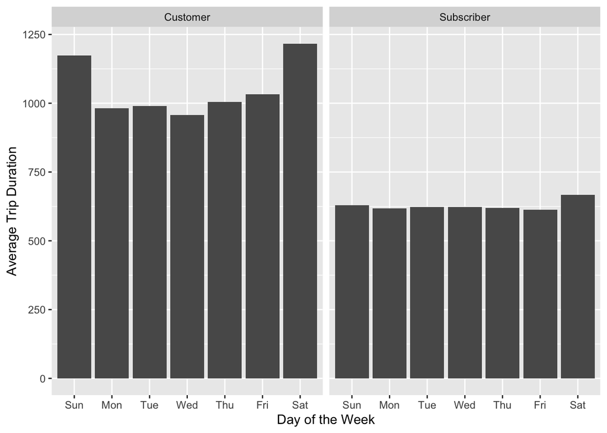

**I consider this is because a lot of customers are tourists, or do not ride a bike on daily basis.**

**A lot of them use bikes as a leisure, not just as a means of transportation.**

The fact that the trip duration on Saturdays and Sundays are longer than other days of the week supports this hypothesis, too.

**On the other hand, subscribers tend to ride almost the same distance, throughout the week. This is probably because it is necessary for them to ride a bike in their life.**

They ride a bike less as a leisure, than customers.

#### Graph.2

- The distributions of birth years, for customers and subscribers

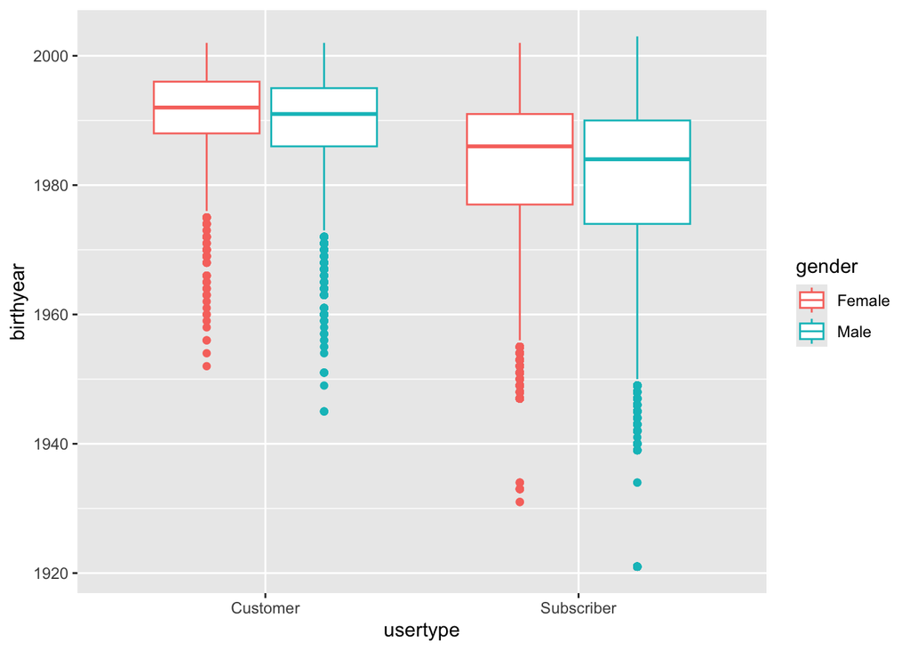

**Those with the age of 35~45 might have more money to pay for the annual plan, and less physical endurance than younger people.**

**In addition, there might be more office workers among those with the age of 35~45 compared to younger generations.**

## Conclusion: how to convert customers to subscribers

Therefore, **the company should display ads or launch campaigns for those who are at the age of about 35 to 45, and live in Chicago, and might need a bike on regular basis, such as office workers.**

With the data set we have explored, I could not dive into deeper.

Especially, I could not clarify exactly what kind of people need to ride a bike on regular basis every day.

If more data sets that can be merged with the data above are provided, I would try to solve it.